# Tutorial: QHScrnomo

## Introduction

The `QHScrnomo` provides functions for fitting and predicting a competing risk model, creating a nomogram, k-fold cross validation, calculating the discrimination metric, and drawing calibration curve. This vignette will walk a reader through the various functions available.

## Setup

Before going through the tutorial, load {QHScrnomo}.

```r
library(QHScrnomo)
sessionInfo()
```

## Example data set

We’ll be using the `prostate.dat` data set throughout this example.

- This is an artificial prostate cancer dataset used for illustrating the usages of functions in `QHScrnomo`
- This is a data frame with 2000 observations on the following 9 variables:
  - `UNIQID`: patient id
  - `TX`: Treatment options of prostate cancer with levels `EBRT`, `PI`, `RP`
  - `PSA`: Pre-treatment PSA levels
  - `BX_GLSN_CAT`: Biopsy Gleason Score Sum. a factor with levels 1 for 2-6 2 for 7 and 3 for 8-10
  - `CLIN_STG`: Clinical stage with levels `T1`, `T2`, `T3`
  - `Age`: Age at treatment date
  - `RACE_AA`: patient ethnicity.a factor with levels 0 for other and 1 for African American
  - `TIME_EVENT`: follow up time in months
  - `EVENT_DOD`: follow status, `0` - censored, `1` - died of prostate cancer, `2` - died of other causes

```r
data("prostate.dat")
str(prostate.dat)
```

```
#> 'data.frame':    2000 obs. of  9 variables:
#>  $ UNIQID     : int  23982340 17299867 35653287 34821801 24377202 20243570 25179226 30671082 26178029 35519165 ...
#>  $ TX         : Factor w/ 3 levels "EBRT","PI","RP": 3 3 3 2 2 3 3 3 3 3 ...
#>  $ PSA        : num  25.2 3.3 7.6 5.6 4.6 4.72 8.2 4.6 3.7 4.23 ...
#>  $ BX_GLSN_CAT: Factor w/ 3 levels "1","2","3": 3 1 1 1 1 1 1 1 1 1 ...
#>  $ CLIN_STG   : Factor w/ 3 levels "T1","T2","T3": 2 1 1 1 1 1 1 1 1 1 ...
#>  $ AGE        : num  57.9 64.6 70.6 65.4 63.8 ...
#>  $ RACE_AA    : num  1 0 0 0 0 0 0 0 0 0 ...
#>  $ TIME_EVENT : num  136.9 87.8 18.7 10.3 7.2 ...
#>  $ EVENT_DOD  : num  0 1 1 0 2 0 1 2 0 0 ...
```

## Fit a competing risk model

The function `crr.fit` uses a Cox proportional hazards regression model constructed from `cph` in `rms` library (by Frank Harrell).

```r
dd <- datadist(prostate.dat)
options(datadist = "dd")
prostate.f <- cph(Surv(TIME_EVENT,EVENT_DOD == 1) ~ TX  + rcs(PSA,3) +
           BX_GLSN_CAT + CLIN_STG + rcs(AGE,3) +
           RACE_AA, data = prostate.dat,
           x = TRUE, y= TRUE, surv=TRUE, time.inc = 144)
prostate.crr <- crr.fit(prostate.f, cencode = 0, failcode = 1)
summary(prostate.crr)
```

```
#>              Effects              Response : Surv(TIME_EVENT, EVENT_DOD == 1)
#>
#>  Factor            Low    High   Diff.  Effect    S.E.     Lower 0.95
#>  PSA                5.000  9.400  4.400 -0.145130 0.074520 -0.291190
#>   Hazard Ratio      5.000  9.400  4.400  0.864910       NA  0.747380
#>  AGE               58.137 69.562 11.425 -0.184680 0.077432 -0.336440
#>   Hazard Ratio     58.137 69.562 11.425  0.831370       NA  0.714310
#>  RACE_AA            0.000  1.000  1.000 -0.252210 0.140700 -0.527970
#>   Hazard Ratio      0.000  1.000  1.000  0.777080       NA  0.589800
#>  TX - EBRT:RP       3.000  1.000     NA -0.066323 0.118050 -0.297700
#>   Hazard Ratio      3.000  1.000     NA  0.935830       NA  0.742530
#>  TX - PI:RP         3.000  2.000     NA  0.238490 0.132460 -0.021125
#>   Hazard Ratio      3.000  2.000     NA  1.269300       NA  0.979100
#>  BX_GLSN_CAT - 2:1  1.000  2.000     NA  0.125530 0.114610 -0.099103
#>   Hazard Ratio      1.000  2.000     NA  1.133800       NA  0.905650
#>  BX_GLSN_CAT - 3:1  1.000  3.000     NA  0.630090 0.161180  0.314180
#>   Hazard Ratio      1.000  3.000     NA  1.877800       NA  1.369100
#>  CLIN_STG - T2:T1   1.000  2.000     NA -0.264760 0.109220 -0.478820
#>   Hazard Ratio      1.000  2.000     NA  0.767390       NA  0.619510
#>  CLIN_STG - T3:T1   1.000  3.000     NA  0.083704 0.214990 -0.337680
#>   Hazard Ratio      1.000  3.000     NA  1.087300       NA  0.713430
#>  Upper 0.95
#>   0.00092617
#>   1.00090000
#>  -0.03291100
#>   0.96762000
#>   0.02355300
#>   1.02380000
#>   0.16505000
#>   1.17950000
#>   0.49809000
#>   1.64560000
#>   0.35016000
#>   1.41930000
#>   0.94600000
#>   2.57540000
#>  -0.05069400
#>   0.95057000
#>   0.50509000
#>   1.65710000
```

## Create nomogram

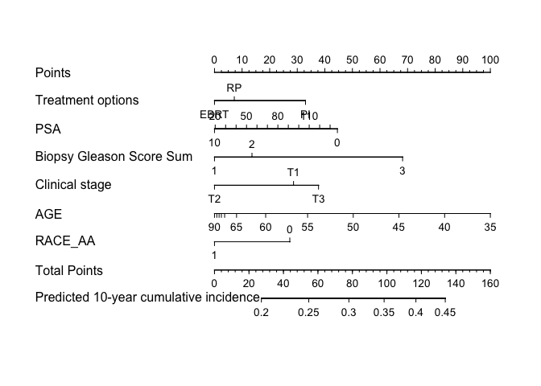

```r
prostate.g <- Newlabels(prostate.crr,
                        c(TX = 'Treatment options',
                          BX_GLSN_CAT = 'Biopsy Gleason Score Sum',
                          CLIN_STG = 'Clinical stage'))
nomogram.crr(prostate.g,
             failtime = 120,
             lp=FALSE,
             xfrac=0.65,
             fun.at = seq(0.2, 0.45, 0.05),
             funlabel = "Predicted 10-year cumulative incidence")
```

```r
# output a math formula
sas.cmprsk(prostate.crr, time = 120)
```

```
#> Base is  0.03949825
#>  0.30480861 * (TX = "PI") + 0.066323409 * (TX = "RP") -
#>     0.05173739 * PSA + 0.00060026412 * max(PSA - 3.8, 0)**3 -
#>     0.00075935137 * max(PSA - 6.335, 0)**3 + 0.00015908725 *
#>     max(PSA - 15.9, 0)**3 + 0.12553095 * (BX_GLSN_CAT = "2") +
#>     0.63008736 * (BX_GLSN_CAT = "3") - 0.26475762 * (CLIN_STG =
#>     "T2") + 0.083704451 * (CLIN_STG = "T3") - 0.030615192 *
#>     AGE + 4.2897617e-05 * max(AGE - 53.318904, 0)**3 - 8.993847e-05 *
#>     max(AGE - 64.190411, 0)**3 + 4.7040853e-05 * max(AGE - 74.104384,
#>     0)**3 - 0.25220729 * RACE_AA
```

## Model evaluation

```r
# anova table
anova(prostate.crr)
```

```
#>                 Wald Statistics          Response: Surv(TIME_EVENT, EVENT_DOD == 1)
#>
#>  Factor          Chi-Square d.f. P
#>  TX               5.21       2   0.0739
#>  PSA              3.85       2   0.1458
#>   Nonlinear       3.79       1   0.0515
#>  BX_GLSN_CAT     15.29       2   0.0005
#>  CLIN_STG         6.88       2   0.0320
#>  AGE              9.27       2   0.0097
#>   Nonlinear       1.35       1   0.2445
#>  RACE_AA          3.21       1   0.0730
#>  TOTAL NONLINEAR  5.16       2   0.0758
#>  TOTAL           44.64      11   <.0001
```

```r
# prediction from 10-fold cross validation
prostate.dat$preds.tenf <- tenf.crr(prostate.crr, time=120, fold = 10)
```

```
#> 1  2  3  4  5  6  7  8  9  10
```

```r
str(prostate.dat$preds.tenf)
```

```
#>  num [1:2000] 0.346 0.336 0.29 0.368 0.4 ...
```

```r
## calculate the CRR version of concordance index
with(prostate.dat, cindex(preds.tenf,
                          ftime = TIME_EVENT,
                          fstatus =EVENT_DOD, type = "crr"))["cindex"]
```

```
#>    cindex
#> 0.5734681
```

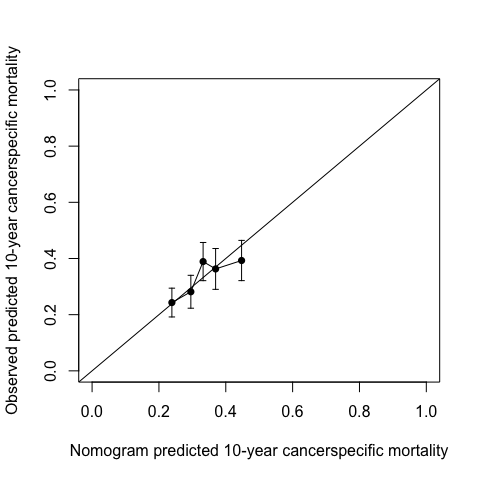

```
#>              x   n events        ci    std.err
#> [1,] 0.2387561 400     87 0.2430994 0.02614273
#> [2,] 0.2954839 400     84 0.2815496 0.02987646
#> [3,] 0.3321609 400    107 0.3890442 0.03467815
#> [4,] 0.3695668 400     85 0.3628186 0.03708080
#> [5,] 0.4472728 400    101 0.3928132 0.03654195
```

```r
## generate the calibration curve for predicted 10-year cancer
## specific mortality
with(prostate.dat,
     groupci(
         preds.tenf,
         ftime = TIME_EVENT,
         fstatus =EVENT_DOD, g = 5, u = 120,
         xlab = "Nomogram predicted 10-year cancerspecific mortality",
         ylab = "Observed predicted 10-year cancerspecific mortality")
)
```